# Exponential distribution

Gerardo Fumagal

2/12/2021

## Exponential distribution and CLT

The exponential distribution is the probability distribution of the time between events in a Poisson point process in which events occur constantly and independently at a constant average rate.

The PDF of an exponential distribution is:

$$\begin{equation}
f(x; \alpha) =
\begin{cases}
\lambda e^\lambda & x \geq 0\\
0 & x \lt 0.\\
\end{cases}
\end{equation}$$

Where $\lambda$ is the key parameter, the mean of the distribution and standard deviation are defined as follows:

$$\begin{equation}
\mu = \frac{\textrm{1}}{\lambda} ; \sigma = \frac{\textrm{1}}{\lambda}
\end{equation}$$

equal to both the mean and the standard deviation of the exponential distribution.

In this paper, we will compare the exponential distribution with the central limit theorem, by simulating the exponential distribution and illustrate its properties.

CLT establishes that the distribution of averages of iid variables normalized, becomes that of a standard normal, as the sample size increases.

If $X_{1} , X_{2} ... X_{i}$ are a collection of iid random variables with mean $\mu$ and variance $\sigma_{2}$; also, let $\bar{X_{n}}$ be their sample average then:

$$\begin{equation}
\frac{\bar{X_{n}} - \mu}{\sigma / \sqrt{n}}
\end{equation}$$

has a distribution of a that of a standard normal for large $n$.

It can be express as the following form:

$$\begin{equation}
\frac{\textrm{Estimate - Mean of estimate}}{\textrm{Std. error of estimate}}
\end{equation}$$

## Simulation

We need to generate the exponential distribution sample, the means and variance, and to normalize them according the the equation by CLT. The following code does generate these simulation, calculate means and normalized them:

```r
lambda <- 0.2
expn <- 100
n <- 1000
meanr <- NULL
meanavg <- NULL
var_exp <- NULL
exp_tonormal <- NULL
var_avg <- NULL
for (i in 1:n) {
  meanr = c(meanr, mean(rexp(expn, lambda)))
  meanavg = c(meanavg, mean(meanr))
  var_exp = c(var_exp, var(rexp(expn, lambda)))
  var_avg = c(var_avg, mean(var_exp))
  SE <- sqrt(var(rexp(expn, lambda))/expn)
  exp_tonormal = c(exp_tonormal,(mean(rexp(expn, lambda))-(1/lambda))/SE)
}
```

## Comparing Exponential Distribution with CLT

1. Sample mean and theoretical mean

We discuss that exponential distribution has a mean of equal to 1/$\lambda$, in our case this value is 5, let’s plot how the simulation behaves as the mean of average sample towards the expected value.

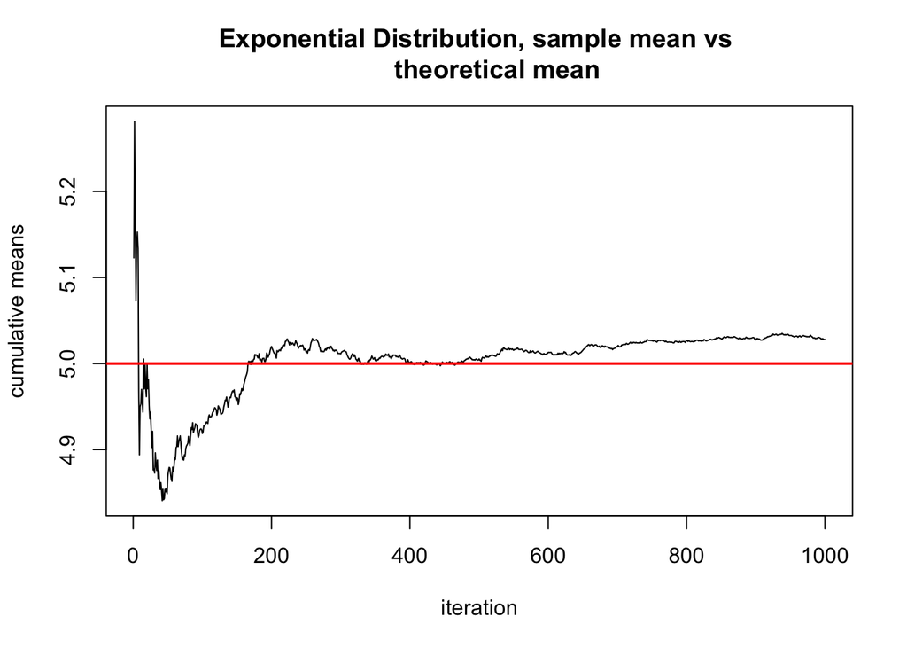

2. Compare how variable the sample is by simulating the variance vs theoretical variance value.

Once again, the standard deviation of the exponential distribution is 1/$\lambda$ which it is also 5, which makes its variance ($S$ = $\sigma^2$) equal to 25.

Let’s plot the results from our simulation and note how they behaves towards the theoretical variance value.

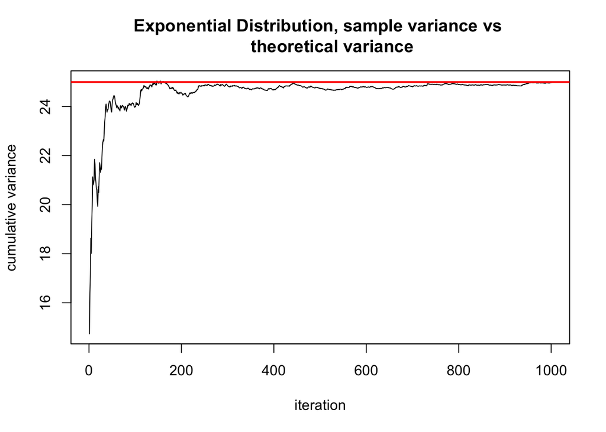

```r
var_theo <- (1/lambda)^2
plot(var_avg, type = "l", main = "Exponential Distribution, sample variance vs
     theoretical variance", ylab = "cumulative variance" , xlab = "iteration")
abline(h=var_theo, lwd = 2, col = "red")
```

The simulation converges to the function’s variance, the sample size is large enough to show the variance value is 25.

3. Is the distribution approximately normal?

We have applied CLT formula on the averages of the samples and store in a variable called exp_tonormal, let’s plot the results and compare to a normal distribution:

[figure not shown]

```r
h <- hist(exp_tonormal, breaks=30, col="red", xlab="x",
   main="Exponential Simulation vs CLT sample size = 40")
xfit <- seq(min(exp_tonormal), max(exp_tonormal), length = 40)
yfit<-dnorm(xfit,mean=mean(exp_tonormal),sd=sd(exp_tonormal))
yfit <- yfit*diff(h$mids[1:2])*length(exp_tonormal)
lines(xfit, yfit, col = "blue", lwd = 2)
```

```r
expn <- 1000
n <- 1000
exp_tonormal <- NULL
for (i in 1:n) {
  SE <- sqrt(var(rexp(expn, lambda))/expn)
  exp_tonormal = c(exp_tonormal,(mean(rexp(expn, lambda))-(1/lambda))/SE)
}
```

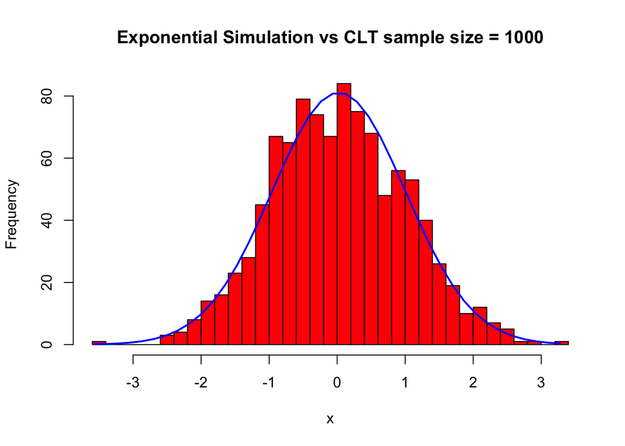